# Guía Regresión lineal múltiple

Curso Introducción al Análisis de datos con R para la acuicultura

Dr. José A. Gallardo y Dra. María Angélica Rueda.

Pontificia Universidad Católica de Valparaíso  
jose.gallardo@pucv.cl

27 July 2021

### MODELOS LINEALES

Sea $Y$ una variable respuesta continua y $X_1,…,X_p$ variables predictoras, un modelo de regresión lineal múltiple se puede representar como,

$$Y_{i} = \beta_{0} + \beta_{1} X_{i1} + \beta_{2} X_{i2} + ... + \beta_{p} X_{ip} + \epsilon_{i}$$

Supuestos:

**1).** No existe multicolinealidad.

**2).** Los residuos distribuyen **normalmente**.

**3).** Existe homogeneidad de varianzas.

#### **Objetivos de aprendizaje**

Los objetivos de aprendizaje de esta guía son:

**1).** Realizar análisis de regresión lineal múltiple.

**2).** Realizar gráficas avanzadas con ggplot2.

**3).** Elaborar un reporte dinámico en formato pdf con **[Rmarkdown](https://rmarkdown.rstudio.com/)**.

## ESTUDIO DE CASO: PRODUCCIÓN DE CAMARONES

En este estudio de caso trabajaremos con un set de datos simulado de 100 camarones cultivados bajo condiciones de campo.

La variable respuesta se denomina **trait_y** y las variables predictoras **Pred_X1**,**Pred_X2**,**Pred_X3**, **Pred_X4**. Todas ellas son variables cuantitativas continuas.

### **Ejercicio 1.** Elaborar y configurar Reporte en formato .Rmd

Elabore un documento .Rmd y configure su reporte para exportar en .pdf. Instale solo las librerías que utilice para el análisis de los datos.

```r
knitr::opts_chunk$set(echo = TRUE)
library(readxl)
library(ggplot2)
library(dplyr)
library(multcomp)
library(psych)
library(car)
```

Ejecute cada uno de los siguientes ejercicios en uno o más bloques de códigos diferentes. Sea ordenado y documente su reporte adecuadamente.

### **Ejercicio 2.** Exploratorio set de datos aqua.dat

Importe el set de datos **aqua.xlsx** y realice un análisis exploratorio de datos.

Incluya:

**a).** Resumen estadístico de todas las variables.

```r
aqua.dat <- read_excel("aqua_dat.xlsx")
summary(aqua.dat)
```

```
##      Shrimp          trait_y         Pred_X1         Pred_X2
##  Min.   :  1.00   Min.   :23.17   Min.   :1.243   Min.   :0.5341
##  1st Qu.: 25.75   1st Qu.:42.79   1st Qu.:2.469   1st Qu.:2.2706
##  Median : 50.50   Median :48.85   Median :3.036   Median :2.9965
##  Mean   : 50.50   Mean   :48.93   Mean   :3.120   Mean   :2.9638
##  3rd Qu.: 75.25   3rd Qu.:55.29   3rd Qu.:3.764   3rd Qu.:3.6887
##  Max.   :100.00   Max.   :64.92   Max.   :5.293   Max.   :5.5715
##     Pred_X3         Pred_X4
##  Min.   :45.36   Min.   : 6.100
##  1st Qu.:48.57   1st Qu.: 8.986
##  Median :49.79   Median : 9.943
##  Mean   :49.80   Mean   : 9.872
##  3rd Qu.:51.03   3rd Qu.:10.893
##  Max.   :54.60   Max.   :13.940
```

**b).** Realice un análisis y gráfica de correlación entre variables respuesta y predictoras.

¿Qué variables predictoras están están altamente correlacionadas entre sí? Recuerde que esto puede ser evidencia de multicolinealidad.

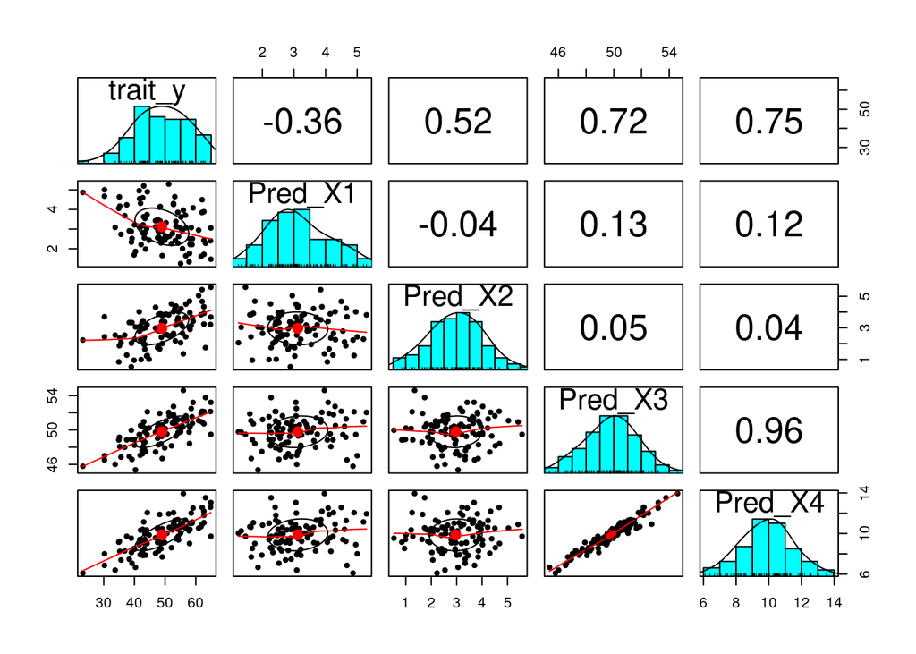

```r
pairs.panels(aqua.dat[2:6])
```

**c).** Histograma de la variable respuesta **trait_y**.

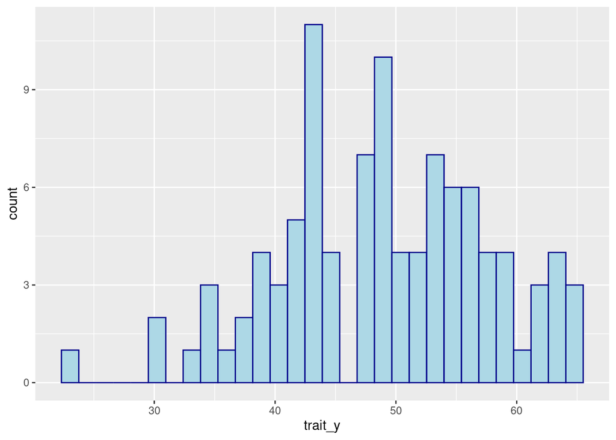

```r
ggplot(aqua.dat, aes(x=trait_y))+
  geom_histogram(color="darkblue", fill="lightblue")
```

### **Ejercicio 3.** Regresión lineal múltiple - modelo completo.

**a).** Realice un análisis de regresión lineal para investigar la asociación entre **trait_y** y todas las variables predictoras usando las funciones **lm()**, **summary()**.

Interprete los resultados del modelo lineal y responda las siguientes preguntas:

- ¿Qué representan los diferentes estimadores Beta?.
- ¿Qué pendientes son significativamente distintas de cero?.
- ¿Cuál es la bondad de ajuste del modelo $R^2$ ajustado?
- ¿Las pendientes de las variables altamente correlacionadas son ambas significativas?

```r
lm.1<-lm(trait_y~Pred_X1+Pred_X2+Pred_X3+Pred_X4,data=aqua.dat)

pander::pander(summary(lm.1), caption = "Modelo de regresión múltiple completo del set de datos aqua.dat")
```

|  | Estimate | Std. Error | t value | Pr(>\|t\|) |
| --- | --- | --- | --- | --- |
| **(Intercept)** | 7.101 | 7.721 | 0.9197 | 0.3601 |
| **Pred_X1** | -4.05 | 0.1047 | -38.7 | 5.892e-60 |
| **Pred_X2** | 3.977 | 0.09506 | 41.83 | 5.379e-63 |
| **Pred_X3** | -0.01023 | 0.1994 | -0.05132 | 0.9592 |
| **Pred_X4** | 4.375 | 0.2328 | 18.79 | 9.237e-34 |

Modelo de regresión múltiple completo del set de datos aqua.dat

| Observations | Residual Std. Error | $R^2$ | Adjusted $R^2$ |
| --- | --- | --- | --- |
| 100 | 0.9794 | 0.988 | 0.9875 |

### **Ejercicio 4.** Evaluación de supuestos modelo completo.

Evalue los supuestos de multicolinealidad, normalidad y homogeneidad de varianzas. Además, realice detección de valores atípicos usando la gráfica del índice de cook (por ejemplo, plot(lm, which=4)).

```r
# Multicolinealidad por vif
vif(lm.1)
```

```
##   Pred_X1   Pred_X2   Pred_X3   Pred_X4
##  1.020348  1.006429 13.851503 13.808926
```

```r
# Normalidad
shapiro.test (residuals (lm.1))
```

```
##
##  Shapiro-Wilk normality test
##
## data:  residuals(lm.1)
## W = 0.99297, p-value = 0.8863
```

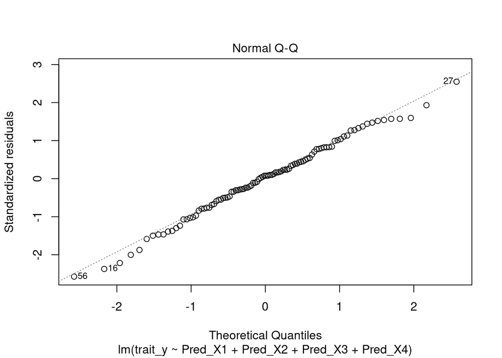

```r
plot(lm.1, which = 2)
```

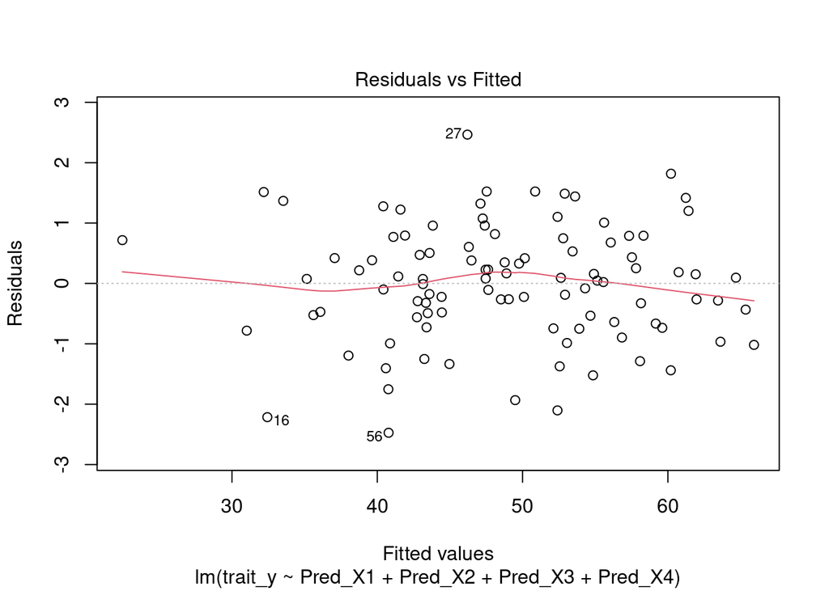

```r
# Homogeneidad de varianzas usando plot
plot(lm.1, which = 1)
```

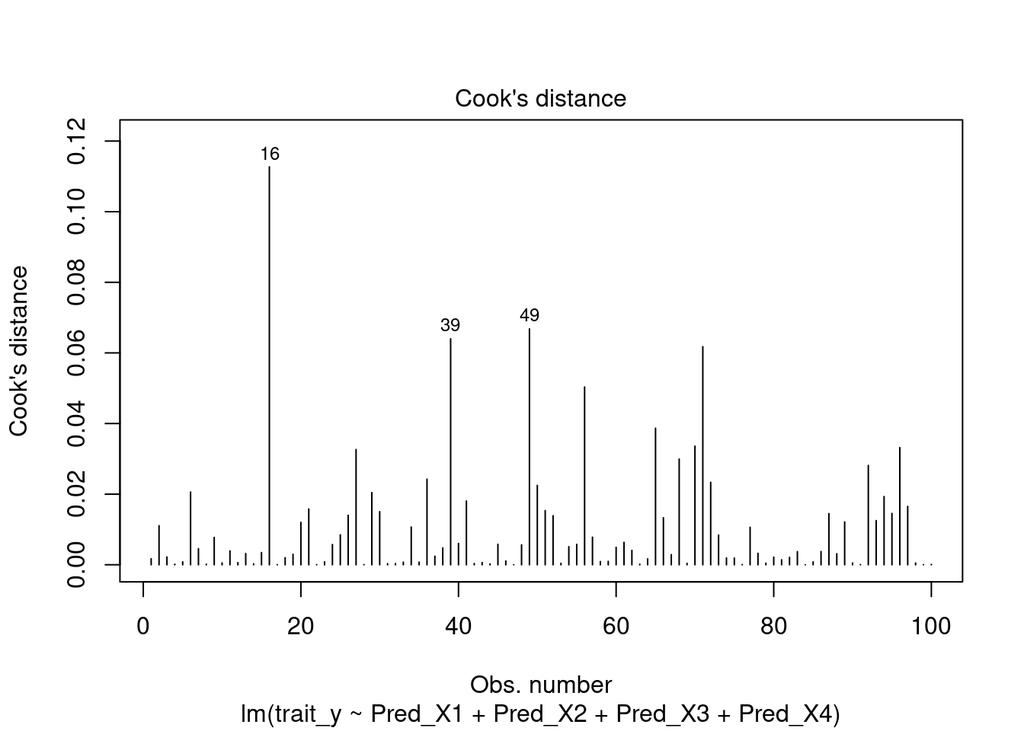

```r
# Indice de Cook
plot(lm.1, which=4)
```

### **Ejercicio 5.** Regresión lineal múltiple - modelo reducido.

Debido al problema de multicolinealidad detectado en el ejercicio anterior se puede decidir en eliminar una de las variables predictoras correlacionadas. En este caso y de forma arbitaria escogeremos la variables **Pred_X3**, pero note que podríamos estar generando un problema de causalidad por variables omitidas. En las próximas clases veremos como resolver esto usando Análisis de Componentes Principales.

**a).** Realice un análisis de regresión lineal para investigar la asociación entre **trait_y** y todas las variables predictoras menos la variable **Pred_X3** usando las funciones **lm()**, **summary()**.

```r
lm.2<-lm(trait_y~Pred_X1+Pred_X2+Pred_X4,data=aqua.dat)

pander::pander(summary(lm.2), caption = "Modelo de regresión múltiple reducido del set de datos aqua.dat")
```

|  | Estimate | Std. Error | t value | Pr(>\|t\|) |
| --- | --- | --- | --- | --- |
| **(Intercept)** | 6.706 | 0.7225 | 9.283 | 5.173e-15 |
| **Pred_X1** | -4.051 | 0.104 | -38.94 | 1.29e-60 |
| **Pred_X2** | 3.976 | 0.09445 | 42.1 | 1.089e-63 |
| **Pred_X4** | 4.363 | 0.06287 | 69.4 | 7.57e-84 |

Modelo de regresión múltiple reducido del set de datos aqua.dat

| Observations | Residual Std. Error | $R^2$ | Adjusted $R^2$ |
| --- | --- | --- | --- |
| 100 | 0.9743 | 0.988 | 0.9876 |

**b).**Evalue nuevamente los supuestos de multicolinealidad, normalidad y homogeneidad de varianzas.

```r
# Multicolinealidad por vif
vif(lm.2)
```

```
##  Pred_X1  Pred_X2  Pred_X4
## 1.018096 1.003868 1.017440
```

```r
# Normalidad
shapiro.test (residuals (lm.1))
```

```
##
##  Shapiro-Wilk normality test
##
## data:  residuals(lm.1)
## W = 0.99297, p-value = 0.8863
```

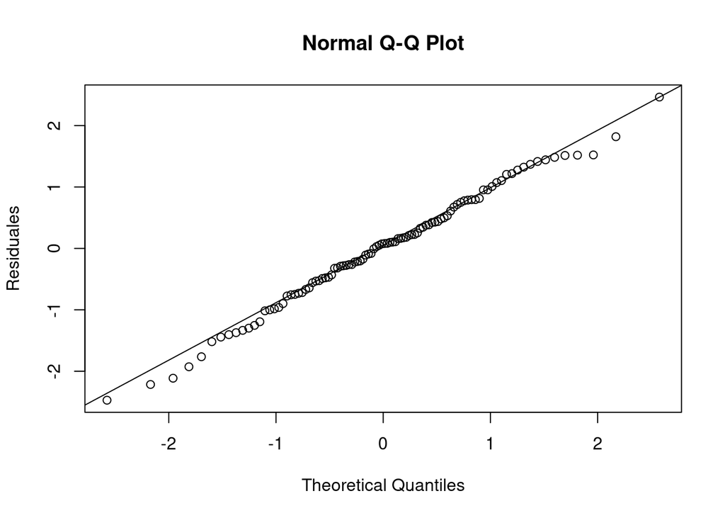

```r
qqnorm (residuals (lm.2), ylab="Residuales")
qqline (residuals (lm.2))
```

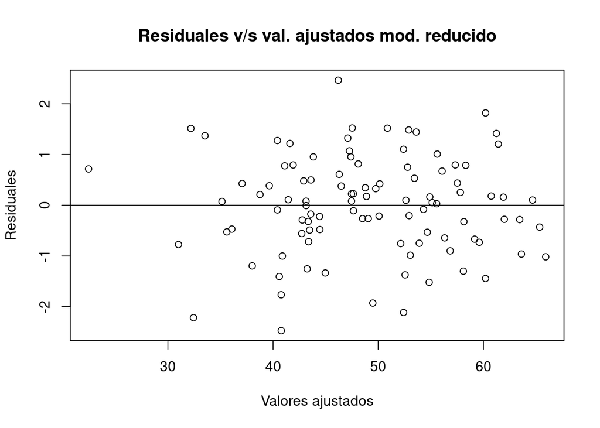

```r
# Homogeneidad de varianzas graficando los residuales y los valores ajustados desde el modelo

plot (x=fitted (lm.2), y= residuals (lm.2), xlab="Valores ajustados", ylab="Residuales", main = "Residuales v/s val. ajustados mod. reducido")
abline (h=0)
```

### **Ejercicio 6.** Comparación modelo completo y modelo reducido.

Compare los modelos completo y reducido usando los residuales, y los criterios AIC y BIC.

- ¿Cuál es el mejor modelo?

```r
# Comparación usando residuales
res <- anova(lm.1, lm.2)
pander::pander(res, caption = "Comparación modelos usando residuales")
```

Comparación modelos usando residuales

| Res.Df | RSS | Df | Sum of Sq | F | Pr(>F) |
| --- | --- | --- | --- | --- | --- |
| 95 | 91.12 | NA | NA | NA | NA |
| 96 | 91.13 | -1 | -0.002526 | 0.002634 | 0.9592 |

```r
# Comparación usando AIC
aic <- AIC(lm.1, lm.2)

pander::pander(aic, caption = "Comparación modelos usando AIC")
```

Comparación modelos usando AIC

|  | df | AIC |
| --- | --- | --- |
| **lm.1** | 6 | 286.5 |
| **lm.2** | 5 | 284.5 |

```r
# Comparación usando BIC
bic <- BIC(lm.1, lm.2)

pander::pander(bic, caption = "Comparación modelos usando BIC")
```

Comparación modelos usando BIC

|  | df | BIC |
| --- | --- | --- |
| **lm.1** | 6 | 302.1 |
| **lm.2** | 5 | 297.5 |